# ru_roberta_fixed

## Демонстрация дообучения (fine-tuning) русскоязычной модели `ruRoBERTa-large`

## Содержание

1. Описание  
2. Параметры  
3. Загрузка корпусов  
4. Предобработка корпусов  
5. Токенизация  
6. Определение размера входа  
7. Подготовка наборов данных  
8. Создание классов  
9. Конфигурация модели  
10. Загрузка модели  
11. Параметры обучения  
12. Подбор гиперпараметров  
13. Обучение на всем обучающем корпусе  
14. Получение оценок на тестовом корпусе  
15. Классификация произвольного текста

### 1. Описание

В ноутбуке демонстрируется классификация по тональности корпуса твитов о банках `SentiRuEval-2015` с использованием модели `ruRoBERTa-large` от Сбера.

Исходные классы библиотеки `transformers` – `RobertaForSequenceClassification` и `RobertaClassificationHead` – модифицируются с целью организации выбора для классификации либо вектора первого токена (аналог токена `[CLS]`), либо среднего вектора по всем векторам выходных токенов.  
За этот выбор отвечает параметр `cls_token`: `True` – если необходимо использовать первый токен, `False` – если нужно усреднение.

#### Ссылки

Модель `ruRoBERTa-large` от Сбера: https://habr.com/ru/company/sberbank/blog/567776/

Зоопарк моделей от Сбера: https://github.com/sberbank-ai/model-zoo

Репозиторий `ruRoBERTa-large` на HuggingFace: https://huggingface.co/ai-forever/ruRoberta-large

Примеры в Google Colab: https://colab.research.google.com/github/sberbank-ai/model-zoo/blob/master/examples/Sber_ai_examples.ipynb

Результаты на Russian SuperGLUE: https://russiansuperglue.com/leaderboard/2

### 2. Параметры

Ноутбук рекомендуется запускать в бесплатном Google Colab – у модели повышенные требования по памяти GPU.

```python
%%shell
pip install -U transformers
pip install -U datasets
```

```python
# Подключаем Google Drive
from google.colab import drive
drive.mount('/content/drive')
```

```python
from transformers import AutoTokenizer, AutoConfig, RobertaPreTrainedModel, RobertaModel, Trainer, TrainingArguments
from transformers.modeling_outputs import SequenceClassifierOutput
from datasets import Dataset
from tokenizers.decoders import ByteLevel
import torch
from torch import nn
from torch.nn import BCEWithLogitsLoss, CrossEntropyLoss, MSELoss
from torch.nn.functional import softmax
import numpy as np
import re
import pandas as pd
import seaborn as sns
import matplotlib.pyplot as plt
import random
from sklearn.model_selection import train_test_split
from sklearn.metrics import confusion_matrix, classification_report, accuracy_score, precision_recall_fscore_support
```

```python
# Путь каталогу с данными на Google Drive
path = "drive/MyDrive/colab_data/ru_roberta/"
```

```python
# Название модели в HuggingFace (https://huggingface.co/sberbank-ai/ruRoberta-large)
model_name = 'ai-forever/ruRoberta-large'
```

```python
# Папка для сохранения финальной обученной модели
save_model_folder = path + 'fine_tuned_model'
```

```python
# Названия файлов корпусов
train_filename = path + 'sentirueval2015_bank_train.csv'
test_filename = path + 'sentirueval2015_bank_test.csv'
```

```python
# Количество классов в корпусах (позитивный 1, негативный -1, нейтральный 0)
num_labels = 3
```

```python
# Использование для классификации:
# True – только первый токен, False – усреднение по всем токенам
cls_token = False
```

```python
# Константа для инициализации генераторов случайных чисел - для воспроизводимости результатов
seed = 42
```

```python
# Размер валидационного датасета при настройке гиперпараметров
validation_size = 0.2
```

```python
# Параметры обучения (для TrainingArguments)
training_output_dir = './training_results' # выходной каталог
overwrite_output_dir = True                # перезаписывать ли контрольные точки
save_steps = 5000                          # количество шагов до обновления контрольной точки
num_train_epochs = 5                       # количество эпох обучения
batch_size = 8                             # размер батча при обучении
weight_decay = 0.01                        # коэффициент регуляризации
learning_rate = 1e-5                       # скорость обучения
training_logging_dir = './logs'            # каталог для логов
evaluation_strategy = 'epoch'              # 'no', 'steps', 'epoch' (оценка в конце каждой эпохи)
```

```python
# Количество знаков после десятичной точки при выводе результатов классификации
digits = 4
```

```python
!nvidia-smi
```

```
Fri Apr 14 01:52:35 2023
+-----------------------------------------------------------------------------+
| NVIDIA-SMI 527.41       Driver Version: 527.41       CUDA Version: 12.0     |
|-------------------------------+----------------------+----------------------+
| GPU  Name            TCC/WDDM | Bus-Id        Disp.A | Volatile Uncorr. ECC |
| Fan  Temp  Perf  Pwr:Usage/Cap|         Memory-Usage | GPU-Util  Compute M. |
|                               |                      |               MIG M. |
|===============================+======================+======================|
|   0  NVIDIA GeForce ... WDDM  | 00000000:01:00.0 Off |                  N/A |
| N/A   40C    P8    12W /  N/A |      0MiB /  6144MiB |      0%      Default |
|                               |                      |                  N/A |
+-------------------------------+----------------------+----------------------+

+-----------------------------------------------------------------------------+
| Processes:                                                                  |
|  GPU   GI   CI        PID   Type   Process name                  GPU Memory |
|        ID   ID                                                   Usage      |
|=============================================================================|
|  No running processes found                                                 |
+-----------------------------------------------------------------------------+
```

### 3. Загрузка корпусов

```python
df_train_init = pd.read_csv(train_filename, sep='\t', header=0)
df_train_init
```

|  | label | text |
| --- | --- | --- |
| 0 | 0 | http://t.co/YEVHuvVGA1 Взять кредит тюмень аль... |
| 1 | 0 | Мнение о кредитной карте втб 24 http://t.co/SB... |
| 2 | 0 | «Райффайзенбанк»: Снижение ключевой ставки ЦБ ... |
| 3 | 0 | Современное состояние кредитного поведения в р... |
| 4 | 1 | @sawik_shuster @YevhenS Главное чтоб банки СБЕ... |
| ... | ... | ... |
| 4878 | 1 | Wiener Boerse решила оставить ВТБ и Сбербанк в... |
| 4879 | 0 | Кредит на покупку недвижимости сбербанк http:/... |
| 4880 | 0 | Как пользоваться кредитной картой visa сбербан... |
| 4881 | 0 | @sberbank Оплатила 11.08.14 через моб.банк нал... |
| 4882 | 0 | @sberbank зачислен. На сайте Сбербанка по отзы... |

4883 rows × 2 columns

```python
df_test = pd.read_csv(test_filename, sep='\t', header=0)
df_test
```

|  | label | text |
| --- | --- | --- |
| 0 | 0 | RT @BosayaKrysa: список аккредитованных оценщи... |
| 1 | 0 | кредит в сбербанке лпх http://t.co/5oBqp3xhAI |
| 2 | 0 | RT @olgakissM: оценка для сбербанка http://t.c... |
| 3 | 0 | RT @TsOlOmInA: разобралась со Сбербанком, бегу... |
| 4 | 0 | рассчитать жилищный кредит в сбербанке http://... |
| ... | ... | ... |
| 4529 | 1 | #newz_day Банк УРАЛСИБ повысил ставки по вклад... |
| 4530 | 0 | хэй.я знаю,что ты заказывала одну вещь с офф с... |
| 4531 | 0 | Это радует - Банк Уралсиб и Фольксваген банк Р... |
| 4532 | 0 | При финансовой поддержке Россельхозбанка постр... |
| 4533 | 0 | Новая машина в кредит С Россельхозбанком прост... |

4534 rows × 2 columns

### 4. Предобработка корпусов

Выводим распределение по классам:

```
 0    3470
-1    1059
 1     354
Name: label, dtype: int64
```

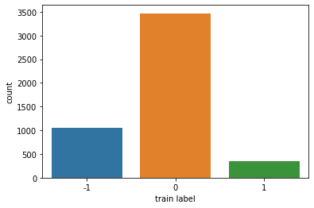

```python
# Выводим распределение по классам
print(df_train_init.label.value_counts())
sns.countplot(x=df_train_init.label)
plt.xlabel('train label');
```

```
 0    3534
-1     654
 1     346
Name: label, dtype: int64
```

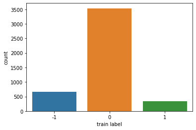

```python
# Выводим распределение по классам
print(df_test.label.value_counts())
sns.countplot(x=df_test.label)
plt.xlabel('train label');
```

Преобразуем метки к множеству {0, 1, 2}:

- `–1` → `0` (негативные)
- `0` → `1` (нейтральные)
- `1` → `2` (позитивные)

```python
change_values = {-1: 0, 0: 1, 1: 2}
```

```python
# Соответствие числовых меток (индексов в данном списке) классам тональности:
# 'negative': 0, 'neutral': 1, 'positive': 2
class_names = ['negative', 'neutral', 'positive']
```

```python
df_train_init.label = df_train_init.label.replace(change_values)
df_train_init
```

|  | label | text |
| --- | --- | --- |
| 0 | 1 | http://t.co/YEVHuvVGA1 Взять кредит тюмень аль... |
| 1 | 1 | Мнение о кредитной карте втб 24 http://t.co/SB... |
| 2 | 1 | «Райффайзенбанк»: Снижение ключевой ставки ЦБ ... |
| 3 | 1 | Современное состояние кредитного поведения в р... |
| 4 | 2 | @sawik_shuster @YevhenS Главное чтоб банки СБЕ... |
| ... | ... | ... |
| 4878 | 2 | Wiener Boerse решила оставить ВТБ и Сбербанк в... |
| 4879 | 1 | Кредит на покупку недвижимости сбербанк http:/... |
| 4880 | 1 | Как пользоваться кредитной картой visa сбербан... |
| 4881 | 1 | @sberbank Оплатила 11.08.14 через моб.банк нал... |
| 4882 | 1 | @sberbank зачислен. На сайте Сбербанка по отзы... |

4883 rows × 2 columns

```python
df_test.label = df_test.label.replace(change_values)
df_test
```

|  | label | text |
| --- | --- | --- |
| 0 | 1 | RT @BosayaKrysa: список аккредитованных оценщи... |
| 1 | 1 | кредит в сбербанке лпх http://t.co/5oBqp3xhAI |
| 2 | 1 | RT @olgakissM: оценка для сбербанка http://t.c... |
| 3 | 1 | RT @TsOlOmInA: разобралась со Сбербанком, бегу... |
| 4 | 1 | рассчитать жилищный кредит в сбербанке http://... |
| ... | ... | ... |
| 4529 | 2 | #newz_day Банк УРАЛСИБ повысил ставки по вклад... |
| 4530 | 1 | хэй.я знаю,что ты заказывала одну вещь с офф с... |
| 4531 | 1 | Это радует - Банк Уралсиб и Фольксваген банк Р... |
| 4532 | 1 | При финансовой поддержке Россельхозбанка постр... |
| 4533 | 1 | Новая машина в кредит С Россельхозбанком прост... |

4534 rows × 2 columns

```
1    3470
0    1059
2     354
Name: label, dtype: int64
```

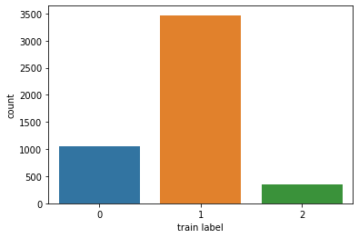

```python
# Выводим распределение по классам
print(df_train_init.label.value_counts())
sns.countplot(x=df_train_init.label)
plt.xlabel('train label');
```

```
1    3534
0     654
2     346
Name: label, dtype: int64
```

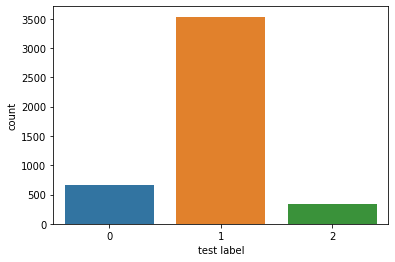

```python
# Выводим распределение по классам
print(df_test.label.value_counts())
sns.countplot(x=df_test.label)
plt.xlabel('test label');
```

```python
# Устанавливаем ширину поля для вывода DataFrame
pd.options.display.max_colwidth = 70
```

```python
df_train_init.head(10)
```

|  | label | text |
| --- | --- | --- |
| 0 | 1 | http://t.co/YEVHuvVGA1 Взять кредит тюмень альфа банк |
| 1 | 1 | Мнение о кредитной карте втб 24 http://t.co/SBJTcsqjCg |
| 2 | 1 | «Райффайзенбанк»: Снижение ключевой ставки ЦБ на заседании в эту п... |
| 3 | 1 | Современное состояние кредитного поведения в россии сбербанк http:... |
| 4 | 2 | @sawik_shuster @YevhenS Главное чтоб банки СБЕР и ВТБ!!! |
| 5 | 1 | http://t.co/Qr6JbSVTxY Оформить краткосрочный кредит оао банк москвы |
| 6 | 2 | Самый выгодный автокредит в втб 24 http://t.co/CDJ5P40x7g |
| 7 | 1 | Похоже завтра Сбербанк и ВТБ присоединяется к национальной неоплат... |
| 8 | 1 | Кредит иногородним в москве сбербанк http://t.co/AVlmacmlSf |
| 9 | 1 | Кредитный калькулятор россельхозбанк чита http://t.co/EqtmPota1G |

Заменяем URL на слово "URL", e-mail – на "mail", имена пользователей – на "user", номера телефонов – на "phone":

```python
def replace_url(text, url_token):
    regex = r"(?i)\b((?:https?://|www\d{0,3}[.]|[a-z0-9.\-]+[.][a-z]{2,4}/)(?:[^\s()<>]+|\(([^\s()<>]+|(\([^\s()<>]+\)))*\))+(?:\(([^\s()<>]+|(\([^\s()<>]+\)))*\)|[^\s`!()\[\]{};:'\".,<>?«»“”‘’]))"

    replaced_text = re.sub(regex, url_token, text)

    return replaced_text
```

```python
def replace_email(text, email_token):
    regex = r'[\w\.-]+@[\w\.-]+'

    replaced_text = re.sub(regex, email_token, text)

    return replaced_text
```

```python
def replace_user(text, user_token):
    regex = r'(?<![@\w])@(\w{1,25})'

    replaced_text = re.sub(regex, user_token, text)

    return replaced_text
```

```python
def replace_phone(text, phone_token):
    regex = r'\+[-()\s\d]+?(?=\s*[+<])'

    replaced_text = re.sub(regex, phone_token, text)

    return replaced_text
```

```python
df_train_init['text_transform'] = df_train_init['text']
df_test['text_transform'] = df_test['text']

df_train_init['text_transform'] = np.vectorize(replace_url)(df_train_init['text_transform'], 'URL')
df_test['text_transform'] = np.vectorize(replace_url)(df_test['text_transform'], 'URL')

df_train_init['text_transform'] = np.vectorize(replace_email)(df_train_init['text_transform'], 'mail')
df_test['text_transform'] = np.vectorize(replace_email)(df_test['text_transform'], 'mail')

df_train_init['text_transform'] = np.vectorize(replace_user)(df_train_init['text_transform'], 'user')
df_test['text_transform'] = np.vectorize(replace_user)(df_test['text_transform'], 'user')

df_train_init['text_transform'] = np.vectorize(replace_phone)(df_train_init['text_transform'], 'phone')
df_test['text_transform'] = np.vectorize(replace_phone)(df_test['text_transform'], 'phone')
```

```python
df_train_init.head(10)
```

|  | label | text | text_transform |
| --- | --- | --- | --- |
| 0 | 1 | http://t.co/YEVHuvVGA1 Взять кредит тюмень альфа банк | URL Взять кредит тюмень альфа банк |
| 1 | 1 | Мнение о кредитной карте втб 24 http://t.co/SBJTcsqjCg | Мнение о кредитной карте втб 24 URL |
| 2 | 1 | «Райффайзенбанк»: Снижение ключевой ставки ЦБ на заседании в эту п... | «Райффайзенбанк»: Снижение ключевой ставки ЦБ на заседании в эту п... |
| 3 | 1 | Современное состояние кредитного поведения в россии сбербанк http:... | Современное состояние кредитного поведения в россии сбербанк URL |
| 4 | 2 | @sawik_shuster @YevhenS Главное чтоб банки СБЕР и ВТБ!!! | user user Главное чтоб банки СБЕР и ВТБ!!! |
| 5 | 1 | http://t.co/Qr6JbSVTxY Оформить краткосрочный кредит оао банк москвы | URL Оформить краткосрочный кредит оао банк москвы |
| 6 | 2 | Самый выгодный автокредит в втб 24 http://t.co/CDJ5P40x7g | Самый выгодный автокредит в втб 24 URL |
| 7 | 1 | Похоже завтра Сбербанк и ВТБ присоединяется к национальной неоплат... | Похоже завтра Сбербанк и ВТБ присоединяется к национальной неоплат... |
| 8 | 1 | Кредит иногородним в москве сбербанк http://t.co/AVlmacmlSf | Кредит иногородним в москве сбербанк URL |
| 9 | 1 | Кредитный калькулятор россельхозбанк чита http://t.co/EqtmPota1G | Кредитный калькулятор россельхозбанк чита URL |

### 5. Токенизация

В `ruRoBERTa` используется токенизатор Byte-level BPE ([BBPE](https://medium.com/@pierre_guillou/byte-level-bpe-an-universal-tokenizer-but-aff932332ffe)) от `ruGPT-2` (а тот, в свою очередь, токенизатор `gpt-2`).

Исходная статья: https://arxiv.org/pdf/1909.03341.pdf.

Полезные ссылки:

- https://github.com/huggingface/tokenizers/issues/203
- https://github.com/huggingface/tokenizers/issues/254
- https://github.com/huggingface/tokenizers/issues/268

```python
tokenizer = AutoTokenizer.from_pretrained(model_name)
tokenizer
```

```
PreTrainedTokenizerFast(name_or_path='sberbank-ai/ruRoberta-large', vocab_size=50257, model_max_len=1000000000000000019884624838656, is_fast=True, padding_side='right', truncation_side='right', special_tokens={'bos_token': AddedToken("<s>", rstrip=False, lstrip=False, single_word=False, normalized=T…
```

```python
# Поля токенизатора
tokenizer.init_kwargs
```

```
{'add_prefix_space': False,
 'bos_token': AddedToken("<s>", rstrip=False, lstrip=False, single_word=False, normalized=True),
 'cls_token': AddedToken("<s>", rstrip=False, lstrip=False, single_word=False, normalized=True),
 'eos_token': AddedToken("</s>", rstrip=False, lstrip=False, single_word=False, normalized=True),
 'errors': 'replace',
 'mask_token': AddedToken("<mask>", rstrip=False, lstrip=True, single_word=False, normalized=True),
 'name_or_path': 'sberbank-ai/ruRoberta-large',
 'pad_token': AddedToken("<pad>", rstrip=False, lstrip=False, single_word=False, normalized=True),
 'sep_token': AddedToken("</s>", rstrip=False, lstrip=False, single_word=False, normalized=True),
 'special_tokens_map_file': None,
 'tokenizer_file': None,
 'trim_offsets': True,
 'unk_token': AddedToken("<unk>", rstrip=False, lstrip=False, single_word=False, normalized=True)}
```

```python
# Размер словаря
tokenizer.vocab_size
```

```
50257
```

```python
# Фрагмент словаря
list(tokenizer.vocab.keys())[:10]
```

```
['ÑħÐ°ÑĥÑģ',
 'ÑģÐºÐ¾Ð¹',
 'ĠÐ¿Ð¾Ð²ÑĭÑĪÐµÐ½Ð½Ð¾Ð¹',
 'Ð¸Ð´Ð°Ñı',
 'ÐļÑĥÐ±',
 'ĠÐ¿Ð¾Ð¿ÑĢÐ¾Ð±Ð¾Ð²Ð°Ð»Ð°',
 'ĠÑģÐºÐ¾Ð»ÑĮÐ·Ð½ÑĥÐ»Ð¸',
 'ĠÐĲÐ»ÐµÐº',
 'ĠÐ¡Ð²Ð¸Ð½',
 'ĠÐĴÐ»Ð°Ð´Ð¸Ð¼Ð¸ÑĢÐ°']
```

Токенизатор `ruRoBERTa` (и `GPT-2`) работает на основе байтов UTF-8, а не на основе символов. Это позволяет сократить базовый словарь до 256 символов (байт) ([ссылка](https://huggingface.co/docs/transformers/tokenizer_summary#bytelevel-bpe)).

Символы кириллицы кодируются следующим образом:

1. используется код символа в UTF-8, например, для буквы 'а' – D0B0 (два байта) ([ссылка](https://i.voenmeh.ru/kafi5/Kam.loc/inform/UTF-8.htm));
2. эти два байта представляются в виде двух символов Unicode: 00D0 ('Ð') и 00B0 ('°') ([ссылка](https://unicode-table.com/ru/00D0/));
3. в результате буква 'а' кодируются символами 'Ð°'.

Если байт из кодировки UTF-8 в кодировке Unicode является управляющим (0080-00FF) ([ссылка](https://unicode-table.com/ru/blocks/latin-1-supplement/)), например, код 0090 ([ссылка](https://unicode-table.com/ru/0090/)), то к этому коду прибавляется шестнадцатеричное число 00A2.  
Например, буква 'А' имеет код D090 в UTF-8. Первый байт представляется в виде символа 'Ð' (код Unicode 00D0), а второй байт является управляющим (0090), поэтому к нему прибавляется 00A2, получается 0132 (символ 'Ĳ').  
Таким образом, буква 'А' представляется символами 'ÐĲ'.

Для декодирования токенов можно использовать класс `ByteLevel` из библиотеки `tokenizers`:

```python
decoder = ByteLevel()
```

```python
decoder.decode(['ÐĲ'])
```

```
'А'
```

Как и в BERT, токенизатор `ruRoBERTa` разбивает слова, для которых нет отдельных токенов в словаре, на токены-подслова.  
Особенностью токенизатора `ruRoBERTa` является то, что для токенов, входящих в состав некоторого слова, используется не признак '##' в начале токена, а отсутствие пробела (символ 'Ġ') в начале токена ([ссылка1](https://stackoverflow.com/questions/61134275/difficulty-in-understanding-the-tokenizer-used-in-roberta-model), [ссылка2](https://github.com/openai/gpt-2/issues/80)).  
Например, строка *'мама мыла раму'* разделится на следующие токены:

- 'Ð¼' – 'м'
- 'Ð°Ð¼Ð°' – 'ама' (в начале нет символа-пробела)
- 'ĠÐ¼ÑĭÐ»Ð°' – ' мыла' (в начале есть символ-пробел)
- 'ĠÑĢÐ°Ð¼' – ' рам' (в начале есть символ-пробел)
- 'Ñĥ' – 'у' (в начале нет символа-пробела)

Пример работы токенизатора:

```python
text = 'мама мыла раму'
text
```

```
'мама мыла раму'
```

```python
tokens = tokenizer.tokenize(text)
tokens
```

```
['Ð¼', 'Ð°Ð¼Ð°', 'ĠÐ¼ÑĭÐ»Ð°', 'ĠÑĢÐ°Ð¼', 'Ñĥ']
```

```python
inputs = tokenizer(text, return_tensors='pt')
inputs
```

```
{'input_ids': tensor([[    1,   287,  2027, 37022,  4257,   272,     2]]), 'attention_mask': tensor([[1, 1, 1, 1, 1, 1, 1]])}
```

```python
tokenizer.convert_ids_to_tokens(inputs['input_ids'][0])
```

```
['<s>', 'Ð¼', 'Ð°Ð¼Ð°', 'ĠÐ¼ÑĭÐ»Ð°', 'ĠÑĢÐ°Ð¼', 'Ñĥ', '</s>']
```

```python
tokenizer.decode(inputs['input_ids'][0])
```

```
'<s>мама мыла раму</s>'
```

### 6. Определение размера входа

Модель `ruRoBERTa` требует фиксированного размера входа (максимум – 512 токенов, не включая два служебных в начале и в конце).  
Для определения размера входа проанализируем текстовый корпус.

```python
def get_token_len(df, tokenizer):
    '''Функция для входного Dataframe возвращает список размеров текстов в токенах'''
    token_lens = []
    for txt in df.text:
        tokens = tokenizer.encode(txt)
        token_lens.append(len(tokens))
    return token_lens
```

```
min length = 5 tokens
max length = 84 tokens
```

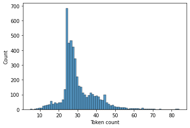

```python
token_lens_train = get_token_len(df_train_init, tokenizer)
print(f'min length = {min(token_lens_train)} tokens')
print(f'max length = {max(token_lens_train)} tokens')
sns.histplot(token_lens_train)
#plt.xlim([0, 256]);   # Сжать график
plt.xlabel('Token count');
```

Установим максимальную длину:

```python
MAX_LEN = 100   # MAX_LEN = 512
```

Найдем количество текстов и долю, размер которых больше максимального:

```python
outliers_number_train = sum(len > MAX_LEN for len in token_lens_train)
print(f'{outliers_number_train} from {len(df_train_init)}')
print(outliers_number_train / len(df_train_init))
```

```
0 from 4883
0.0
```

```
min length = 5 tokens
max length = 83 tokens
```

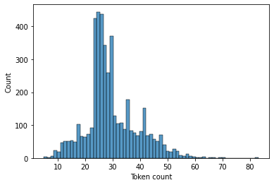

```python
token_lens_test = get_token_len(df_test, tokenizer)
print(f'min length = {min(token_lens_test)} tokens')
print(f'max length = {max(token_lens_test)} tokens')
sns.histplot(token_lens_test)
#plt.xlim([0, 256]);   # Сжать график
plt.xlabel('Token count');
```

```python
outliers_number_test = sum(len > MAX_LEN for len in token_lens_test)
print(f'{outliers_number_test} from {len(df_test)}')
print(outliers_number_test / len(df_test))
```

```
0 from 4534
0.0
```

В качестве размера входа берем `MAX_LEN`.

### 7. Подготовка наборов данных

Для воспроизводимости результатов инициализируем генераторы случайных чисел Python, Numpy и PyTorch:

```python
random.seed(seed)
np.random.seed(seed)
torch.manual_seed(seed)
```

```
<torch._C.Generator at 0x7fcd9e510830>
```

*Замечание*. Полная воспроизводимость результатов таким способом не гарантируется: https://pytorch.org/docs/stable/notes/randomness.html.

```python
# Делим обучающий корпус на обучающую (training) часть и проверочную (validation, evaluation) часть
df_train, df_eval = train_test_split(df_train_init, test_size=validation_size, random_state=seed)
```

```python
print('train init dataset shape:', df_train_init.shape)
print('train dataset shape:', df_train.shape)
print('evaluation dataset shape:', df_eval.shape)
print('\ntest dataset shape:', df_test.shape)
```

```
train init dataset shape: (4883, 3)
train dataset shape: (3906, 3)
evaluation dataset shape: (977, 3)

test dataset shape: (4534, 3)
```

Формируем объекты класса `Dataset`, необходимые для моделей `transformers` (https://huggingface.co/docs/datasets/):

```python
train_init_dataset = Dataset.from_pandas(df_train_init)
train_dataset = Dataset.from_pandas(df_train)
eval_dataset = Dataset.from_pandas(df_eval)
test_dataset = Dataset.from_pandas(df_test)

print(f'train_dataset:\n\n{train_dataset}')
```

```
train_dataset:

Dataset({
    features: ['label', 'text', 'text_transform', '__index_level_0__'],
    num_rows: 3906
})
```

```python
train_dataset[0]
```

```
{'__index_level_0__': 3567,
 'label': 1,
 'text': 'кредиты в ставрополе сбербанк http://t.co/tUiQMEKuKy',
 'text_transform': 'кредиты в ставрополе сбербанк URL'}
```

Определяем функцию для токенизации `Dataset`. Не забываем указать необходимое поле в `DataFrame` (`'text_transform'`):

```python
def tokenize(batch):
    '''Функция для токенизации Dataset'''
    return tokenizer(
        batch['text_transform'],
        max_length=MAX_LEN,
        padding='max_length',        # 'longest', 'max_length', 'do_not_pad'
        truncation='longest_first'
    )
```

Осуществляем токенизацию датасетов:

```python
train_init_dataset = train_init_dataset.map(tokenize, batched=True, batch_size=len(train_init_dataset))
train_dataset = train_dataset.map(tokenize, batched=True, batch_size=len(train_dataset))
eval_dataset = eval_dataset.map(tokenize, batched=True, batch_size=len(eval_dataset))
test_dataset = test_dataset.map(tokenize, batched=True, batch_size=len(test_dataset))
```

```python
# Определяем, что будет возвращать функция __getitem__() для Dataset
train_init_dataset.set_format('torch', columns=['input_ids', 'attention_mask', 'label'])
train_dataset.set_format('torch', columns=['input_ids', 'attention_mask', 'label'])
eval_dataset.set_format('torch', columns=['input_ids', 'attention_mask', 'label'])
test_dataset.set_format('torch', columns=['input_ids', 'attention_mask', 'label'])
```

```python
train_dataset
```

```
Dataset({
    features: ['label', 'text', 'text_transform', '__index_level_0__', 'input_ids', 'attention_mask'],
    num_rows: 3906
})
```

```python
# Вызов должен возвращать только те поля, которые были указаны в train_dataset.set_format:
train_dataset[0]
```

```
{'attention_mask': tensor([1, 1, 1, 1, 1, 1, 1, 1, 1, 1, 1, 1, 1, 1, 0, 0, 0, 0, 0, 0, 0, 0, 0, 0,
         0, 0, 0, 0, 0, 0, 0, 0, 0, 0, 0, 0, 0, 0, 0, 0, 0, 0, 0, 0, 0, 0, 0, 0,
         0, 0, 0, 0, 0, 0, 0, 0, 0, 0, 0, 0, 0, 0, 0, 0, 0, 0, 0, 0, 0, 0, 0, 0,
         0, 0, 0, 0, 0, 0, 0, 0, 0, 0, 0, 0, 0, 0, 0, 0, 0, 0, 0, 0, 0, 0, 0, 0,
         0, 0, 0, 0]),
 'input_ids': tensor([    1,   279,   728,  2674,   281,  2996,  1497,  4353,  2041,  1985,
          3797,  6119, 48126,     2,     0,     0,     0,     0,     0,     0,
             0,     0,     0,     0,     0,     0,     0,     0,     0,     0,
             0,     0,     0,     0,     0,     0,     0,     0,     0,     0,
             0,     0,     0,     0,     0,     0,     0,     0,     0,     0,
             0,     0,     0,     0,     0,     0,     0,     0,     0,     0,
             0,     0,     0,     0,     0,     0,     0,     0,     0,     0,
             0,     0,     0,     0,     0,     0,     0,     0,     0,     0,
             0,     0,     0,     0,     0,     0,     0,     0,     0,     0,
             0,     0,     0,     0,     0,     0,     0,     0,     0,     0]),
 'label': tensor(1)}
```

### 8. Создание классов

#### Новый класс `RobertaFineTuningClassificationHead`

За основу взят класс `RobertaClassificationHead` ([ссылка](https://github.com/huggingface/transformers/blob/2a33734606aa25c6f05df157fff8c52b2a883c33/src/transformers/models/roberta/modeling_roberta.py#L1443)).

В этом классе к выходу модели добавляется двухслойная нейронная сеть.

Изменения в этом классе:

- добавлено поле `self.cls_token` = `config.cls_token`;
- в методе `forward` добавлена проверка поля `self.cls_token`.

```python
class RobertaFineTuningClassificationHead(nn.Module):
    """Head for sentence-level classification tasks."""

    def __init__(self, config):
        super().__init__()
        self.cls_token = config.cls_token
        self.dense = nn.Linear(config.hidden_size, config.hidden_size)
        classifier_dropout = (
            config.classifier_dropout if config.classifier_dropout is not None else config.hidden_dropout_prob
        )
        self.dropout = nn.Dropout(classifier_dropout)
        self.out_proj = nn.Linear(config.hidden_size, config.num_labels)

    def forward(self, features, **kwargs):
        if self.cls_token:
            x = features[:, 0, :]  # take <s> token (equiv. to [CLS])
        else:
            x = torch.mean(features, dim=1) # average all the tokens
        x = self.dropout(x)
        x = self.dense(x)
        x = torch.tanh(x)
        x = self.dropout(x)
        x = self.out_proj(x)
        return x
```

#### Новый класс `RobertaForFineTuningClassification`

За основу взят класс `RobertaForSequenceClassification` ([ссылка](https://github.com/huggingface/transformers/blob/master/src/transformers/models/roberta/modeling_roberta.py#L1162)]).

Единственное изменение в этом классе – заменен классификатор `self.classifier`: вместо класса `RobertaClassificationHead` использован новый класс `RobertaFineTuningClassificationHead`.

```python
class RobertaForFineTuningClassification(RobertaPreTrainedModel):

    def __init__(self, config):
        super().__init__(config)
        self.num_labels = config.num_labels
        self.config = config

        self.roberta = RobertaModel(config, add_pooling_layer=False)
        self.classifier = RobertaFineTuningClassificationHead(config)

        # Initialize weights and apply final processing
        self.post_init()

    def forward(
        self,
        input_ids=None,
        attention_mask=None,
        token_type_ids=None,
        position_ids=None,
        head_mask=None,
        inputs_embeds=None,
        labels=None,
        output_attentions=None,
        output_hidden_states=None,
        return_dict=None,
    ):
        r"""
        labels (:obj:`torch.LongTensor` of shape :obj:`(batch_size,)`, `optional`):
            Labels for computing the sequence classification/regression loss. Indices should be in :obj:`[0, ...,
            config.num_labels - 1]`. If :obj:`config.num_labels == 1` a regression loss is computed (Mean-Square loss),
            If :obj:`config.num_labels > 1` a classification loss is computed (Cross-Entropy).
        """
        return_dict = return_dict if return_dict is not None else self.config.use_return_dict

        outputs = self.roberta(
            input_ids,
            attention_mask=attention_mask,
            token_type_ids=token_type_ids,
            position_ids=position_ids,
            head_mask=head_mask,
            inputs_embeds=inputs_embeds,
            output_attentions=output_attentions,
            output_hidden_states=output_hidden_states,
            return_dict=return_dict,
        )
        sequence_output = outputs[0]
        logits = self.classifier(sequence_output)

        loss = None
        if labels is not None:
            if self.config.problem_type is None:
                if self.num_labels == 1:
                    self.config.problem_type = "regression"
                elif self.num_labels > 1 and (labels.dtype == torch.long or labels.dtype == torch.int):
                    self.config.problem_type = "single_label_classification"
                else:
                    self.config.problem_type = "multi_label_classification"

            if self.config.problem_type == "regression":
                loss_fct = MSELoss()
                if self.num_labels == 1:
                    loss = loss_fct(logits.squeeze(), labels.squeeze())
                else:
                    loss = loss_fct(logits, labels)
            elif self.config.problem_type == "single_label_classification":
                loss_fct = CrossEntropyLoss()
                loss = loss_fct(logits.view(-1, self.num_labels), labels.view(-1))
            elif self.config.problem_type == "multi_label_classification":
                loss_fct = BCEWithLogitsLoss()
                loss = loss_fct(logits, labels)

        if not return_dict:
            output = (logits,) + outputs[2:]
            return ((loss,) + output) if loss is not None else output

        return SequenceClassifierOutput(
            loss=loss,
            logits=logits,
            hidden_states=outputs.hidden_states,
            attentions=outputs.attentions,
        )
```

### 9. Конфигурация модели

```python
config = AutoConfig.from_pretrained(model_name)
config
```

```
RobertaConfig {
  "_name_or_path": "sberbank-ai/ruRoberta-large",
  "architectures": [
    "RobertaForMaskedLM"
  ],
  "attention_probs_dropout_prob": 0.1,
  "bos_token_id": 1,
  "classifier_dropout": null,
  "eos_token_id": 2,
  "gradient_checkpointing": false,
  "hidden_act": "gelu",
  "hidden_dropout_prob": 0.1,
  "hidden_size": 1024,
  "initializer_range": 0.02,
  "intermediate_size": 4096,
  "layer_norm_eps": 1e-05,
  "max_position_embeddings": 514,
  "model_type": "roberta",
  "num_attention_heads": 16,
  "num_hidden_layers": 24,
  "pad_token_id": 1,
  "position_embedding_type": "absolute",
  "transformers_version": "4.16.2",
  "type_vocab_size": 1,
  "use_cache": true,
  "vocab_size": 50265
}
```

Количество классов:

```python
config.num_labels
```

```
2
```

Устанавливаем требемое количество классов:

```python
config.num_labels = num_labels
```

Задаем необходимый режим работы с выходными токенами для классификации.  
Для этого добавляем новое поле в объект `config`:

```python
config.cls_token = cls_token
```

### 10. Загрузка модели

```python
model = RobertaForFineTuningClassification.from_pretrained(model_name, config=config)
```

[output not shown]

```python
model
```

```
RobertaForFineTuningClassification(
  (roberta): RobertaModel(
    (embeddings): RobertaEmbeddings(
      (word_embeddings): Embedding(50265, 1024, padding_idx=1)
      (position_embeddings): Embedding(514, 1024, padding_idx=1)
      (token_type_embeddings): Embedding(1, 1024)
      (LayerNorm): LayerNorm((1024,), eps=1e-05, elementwise_affine=True)
      (dropout): Dropout(p=0.1, inplace=False)
    )
    (encoder): RobertaEncoder(
      (layer): ModuleList(
        (0): RobertaLayer(
          (attention): RobertaAttention(
            (self): RobertaSelfAttention(
              (query): Linear(in_features=1024, out_features=1024, bias=True)
              (key): Linear(in_features=1024, out_features=1024, bias=True)
              (value): Linear(in_features=1024, out_features=1024, bias=True)
              (dropout): Dropout(p=0.1, inplace=False)
            )
            (output): RobertaSelfOutput(
              (dense): Linear(in_features=1024, out_features=1024, bias=True)
              (LayerNorm): LayerNorm((1024,), eps=1e-05, elementwise_affine=True)
              (dropout): Dropout(p=0.1, inplace=False)
            )
          )
          (intermediate): RobertaIntermediate(
            (dense): Linear(in_features=1024, out_features=4096, bias=True)
          )
          (output): RobertaOutput(
            (dense): Linear(in_features=4096, out_features=1024, bias=True)
            (LayerNorm): LayerNorm((1024,), eps=1e-05, elementwise_affine=True)
            (dropout): Dropout(p=0.1, inplace=False)
          )
        )
        (1): RobertaLayer(
          (attention): RobertaAttention(
            (self): RobertaSelfAttention(
              (query): Linear(in_features=1024, out_features=1024, bias=True)
              (key): Linear(in_features=1024, out_features=1024, bias=True)
              (value): Linear(in_features=1024, out_features=1024, bias=True)
```

[output cut: 517 more lines]

```
          (output): RobertaOutput(
            (dense): Linear(in_features=4096, out_features=1024, bias=True)
            (LayerNorm): LayerNorm((1024,), eps=1e-05, elementwise_affine=True)
            (dropout): Dropout(p=0.1, inplace=False)
          )
        )
      )
    )
  )
  (classifier): RobertaFineTuningClassificationHead(
    (dense): Linear(in_features=1024, out_features=1024, bias=True)
    (dropout): Dropout(p=0.1, inplace=False)
    (out_proj): Linear(in_features=1024, out_features=3, bias=True)
  )
)
```

Проверяем количество классов:

```python
assert model.config.num_labels == num_labels
print(model.config.num_labels)
```

```
3
```

```python
assert model.classifier.out_proj.out_features == num_labels
print(model.classifier.out_proj.out_features)
```

```
3
```

```python
# Выводим структуру модели и количество параметров
all_parameters = 0
trainable_parameters = 0
for parameter in model.named_parameters():
    print(f'{parameter[0]}: {list(parameter[1].data.size())} - {parameter[1].numel()}')
    all_parameters += parameter[1].numel()
    if parameter[1].requires_grad:
        trainable_parameters += parameter[1].numel()

print(f'\nAll parameters = {all_parameters}')
print(f'Trainable parameters = {trainable_parameters}')
```

```
roberta.embeddings.word_embeddings.weight: [50265, 1024] - 51471360
roberta.embeddings.position_embeddings.weight: [514, 1024] - 526336
roberta.embeddings.token_type_embeddings.weight: [1, 1024] - 1024
roberta.embeddings.LayerNorm.weight: [1024] - 1024
roberta.embeddings.LayerNorm.bias: [1024] - 1024
roberta.encoder.layer.0.attention.self.query.weight: [1024, 1024] - 1048576
roberta.encoder.layer.0.attention.self.query.bias: [1024] - 1024
roberta.encoder.layer.0.attention.self.key.weight: [1024, 1024] - 1048576
roberta.encoder.layer.0.attention.self.key.bias: [1024] - 1024
roberta.encoder.layer.0.attention.self.value.weight: [1024, 1024] - 1048576
roberta.encoder.layer.0.attention.self.value.bias: [1024] - 1024
roberta.encoder.layer.0.attention.output.dense.weight: [1024, 1024] - 1048576
roberta.encoder.layer.0.attention.output.dense.bias: [1024] - 1024
roberta.encoder.layer.0.attention.output.LayerNorm.weight: [1024] - 1024
roberta.encoder.layer.0.attention.output.LayerNorm.bias: [1024] - 1024
roberta.encoder.layer.0.intermediate.dense.weight: [4096, 1024] - 4194304
roberta.encoder.layer.0.intermediate.dense.bias: [4096] - 4096
roberta.encoder.layer.0.output.dense.weight: [1024, 4096] - 4194304
roberta.encoder.layer.0.output.dense.bias: [1024] - 1024
roberta.encoder.layer.0.output.LayerNorm.weight: [1024] - 1024
roberta.encoder.layer.0.output.LayerNorm.bias: [1024] - 1024
roberta.encoder.layer.1.attention.self.query.weight: [1024, 1024] - 1048576
roberta.encoder.layer.1.attention.self.query.bias: [1024] - 1024
roberta.encoder.layer.1.attention.self.key.weight: [1024, 1024] - 1048576
roberta.encoder.layer.1.attention.self.key.bias: [1024] - 1024
roberta.encoder.layer.1.attention.self.value.weight: [1024, 1024] - 1048576
roberta.encoder.layer.1.attention.self.value.bias: [1024] - 1024
roberta.encoder.layer.1.attention.output.dense.weight: [1024, 1024] - 1048576
roberta.encoder.layer.1.attention.output.dense.bias: [1024] - 1024
roberta.encoder.layer.1.attention.output.LayerNorm.weight: [1024] - 1024
roberta.encoder.layer.1.attention.output.LayerNorm.bias: [1024] - 1024
roberta.encoder.layer.1.intermediate.dense.weight: [4096, 1024] - 4194304
roberta.encoder.layer.1.intermediate.dense.bias: [4096] - 4096
roberta.encoder.layer.1.output.dense.weight: [1024, 4096] - 4194304
roberta.encoder.layer.1.output.dense.bias: [1024] - 1024
roberta.encoder.layer.1.output.LayerNorm.weight: [1024] - 1024
roberta.encoder.layer.1.output.LayerNorm.bias: [1024] - 1024
roberta.encoder.layer.2.attention.self.query.weight: [1024, 1024] - 1048576
roberta.encoder.layer.2.attention.self.query.bias: [1024] - 1024
roberta.encoder.layer.2.attention.self.key.weight: [1024, 1024] - 1048576
```

[output cut: 341 more lines]

```
roberta.encoder.layer.23.attention.output.LayerNorm.weight: [1024] - 1024
roberta.encoder.layer.23.attention.output.LayerNorm.bias: [1024] - 1024
roberta.encoder.layer.23.intermediate.dense.weight: [4096, 1024] - 4194304
roberta.encoder.layer.23.intermediate.dense.bias: [4096] - 4096
roberta.encoder.layer.23.output.dense.weight: [1024, 4096] - 4194304
roberta.encoder.layer.23.output.dense.bias: [1024] - 1024
roberta.encoder.layer.23.output.LayerNorm.weight: [1024] - 1024
roberta.encoder.layer.23.output.LayerNorm.bias: [1024] - 1024
classifier.dense.weight: [1024, 1024] - 1048576
classifier.dense.bias: [1024] - 1024
classifier.out_proj.weight: [3, 1024] - 3072
classifier.out_proj.bias: [3] - 3

All parameters = 355362819
Trainable parameters = 355362819
```

```python
# Выводим веса первого слоя (должны быть одинаковыми после каждой загрузки одной и той же модели)
model.roberta.embeddings.word_embeddings.weight
```

```
Parameter containing:
tensor([[-0.0139,  0.0176,  0.0842,  ..., -0.1384,  0.0302,  0.0301],
        [-0.0330, -0.0119, -0.0009,  ..., -0.1712, -0.0754,  0.0157],
        [-0.0098,  0.0349,  0.0002,  ..., -0.0560, -0.1285, -0.1679],
        ...,
        [-0.0229, -0.0179,  0.0746,  ..., -0.1801, -0.0312,  0.0677],
        [-0.0702, -0.0194,  0.0365,  ..., -0.1703, -0.0627,  0.0696],
        [-0.0201, -0.0217,  0.0524,  ..., -0.2081, -0.0813,  0.0469]],
       requires_grad=True)
```

```python
# Выводим веса последнего слоя - классификатора. Если в загруженной модели этих слоев не было, то они инициализируются случайным образом. Но при инициализации генератора случайных чисел одной и той же константой, они должны быть одинаковыми.
model.classifier.out_proj.weight
```

```
Parameter containing:
tensor([[ 0.0172, -0.0077, -0.0111,  ..., -0.0127, -0.0247,  0.0338],
        [-0.0055,  0.0218, -0.0255,  ...,  0.0262,  0.0254, -0.0543],
        [ 0.0056, -0.0140, -0.0135,  ..., -0.0273,  0.0059,  0.0333]],
       requires_grad=True)
```

### 11. Параметры обучения

```python
def compute_metrics(pred):
    '''Функция возвращает метрики качества'''
    labels = pred.label_ids
    preds = pred.predictions.argmax(-1)
    precision, recall, f1, _ = precision_recall_fscore_support(labels, preds)
    acc = accuracy_score(labels, preds)
    return {
        'accuracy': acc,
        'f1_mean': np.mean(f1),
        'f1': f1.tolist(),
        'precision': precision.tolist(),
        'recall': recall.tolist()
    }
```

```python
# Устанавливаем параметры обучения
training_args = TrainingArguments(
    output_dir=training_output_dir,             # выходной каталог
    overwrite_output_dir=overwrite_output_dir,  # перезаписывать контрольные точки
    save_steps=save_steps,                      # количество шагов до обновления контрольной точки
    num_train_epochs=num_train_epochs,          # количество эпох обучения
    per_device_train_batch_size=batch_size,     # размер батча на устройство при обучении
    per_device_eval_batch_size=batch_size,      # размер батча при оценке
    weight_decay=weight_decay,                  # коэффициент регуляризации
    learning_rate=learning_rate,                # скорость обучения
    logging_dir=training_logging_dir,           # каталог для логов
    evaluation_strategy=evaluation_strategy     # 'no', 'steps', 'epoch' (оценка в конце каждой эпохи)
)
```

```python
# Проверяем, что модель будет использовать GPU
training_args.device
```

```
device(type='cuda', index=0)
```

```python
# Проверяем, что модель изначально загрузилась на cpu
model.device
```

```
device(type='cpu')
```

### 12. Подбор гиперпараметров

Сначала желательно подобрать *гиперпараметры* (hyperparameters) модели – количество эпох обучения, скорость обучения, размер батча, коэффициент регуляризации и т.п. Гиперпараметры подбираются с использованием проверочного (валидационного) набора данных, который выделяется из обучающего (`eval_dataset`).  
В этом примере мы подберем только количество эпох – запустим обучение на `num_train_epochs` эпохах, в конце оценим качество на валидационных данных для каждой эпохи, и выберем оптимальное количество эпох.  
Финальную модель можно строить на основе всего обучающего датасета с выбранными оптимальными гиперпараметрами.

```python
# Создаем объект класса Trainer
# Указываем обучающий и валидационный датасеты
# При создании объекта происходит перемещение модели на gpu и инициализация генератора случайных чисел
trainer = Trainer(
    model=model,
    args=training_args,
    compute_metrics=compute_metrics,
    train_dataset=train_dataset,
    eval_dataset=eval_dataset
)
```

```python
# Проверяем, что Trainer переместил модель на GPU
model.device
```

```
device(type='cuda', index=0)
```

```python
%%time

trainer.train()
```

```
The following columns in the training set  don't have a corresponding argument in `RobertaForFineTuningClassification.forward` and have been ignored: __index_level_0__, text_transform, text.
***** Running training *****
  Num examples = 3906
  Num Epochs = 5
  Instantaneous batch size per device = 8
  Total train batch size (w. parallel, distributed & accumulation) = 8
  Gradient Accumulation steps = 1
  Total optimization steps = 2445
```

[2445/2445 52:14, Epoch 5/5]

| Epoch | Training Loss | Validation Loss | Accuracy | F1 Mean | F1 | Precision | Recall |
| --- | --- | --- | --- | --- | --- | --- | --- |
| 1 | No log | 0.258640 | 0.917093 | 0.749045 | [0.9094922737306843, 0.9480337078651685, 0.38961038961038963] | [0.8512396694214877, 0.9440559440559441, 0.75] | [0.976303317535545, 0.9520451339915373, 0.2631578947368421] |
| 2 | 0.332800 | 0.246855 | 0.938588 | 0.859175 | [0.9327146171693734, 0.9590973201692524, 0.6857142857142857] | [0.9136363636363637, 0.9590973201692524, 0.75] | [0.95260663507109, 0.9590973201692524, 0.631578947368421] |
| 3 | 0.195300 | 0.296154 | 0.940635 | 0.869034 | [0.9400921658986175, 0.96011396011396, 0.706896551724138] | [0.9147982062780269, 0.9697841726618706, 0.6949152542372882] | [0.966824644549763, 0.9506346967559943, 0.7192982456140351] |
| 4 | 0.135600 | 0.300201 | 0.940635 | 0.870096 | [0.9458823529411764, 0.9594882729211087, 0.7049180327868853] | [0.9392523364485982, 0.9670487106017192, 0.6615384615384615] | [0.95260663507109, 0.9520451339915373, 0.7543859649122807] |
| 5 | 0.091600 | 0.325840 | 0.937564 | 0.868524 | [0.9370629370629371, 0.9566453447050461, 0.7118644067796609] | [0.9220183486238532, 0.9641833810888252, 0.6885245901639344] | [0.95260663507109, 0.9492242595204513, 0.7368421052631579] |

[output not shown]

```
CPU times: user 39min 42s, sys: 12min 34s, total: 52min 17s
Wall time: 52min 15s
```

```
TrainOutput(global_step=2445, training_loss=0.1655620785578628, metrics={'train_runtime': 3135.8021, 'train_samples_per_second': 6.228, 'train_steps_per_second': 0.78, 'total_flos': 3554820512082000.0, 'train_loss': 0.1655620785578628, 'epoch': 5.0})
```

Из результатов видно, что максимальное значение F1-score на валидационных данных достигается на 4-й эпохе.

### 13. Обучение на всем обучающем корпусе

Обучим финальную модель на всем обучающем корпусе с оптимальными значениями гиперпараметров, подобранных на предыдущем этапе. Мы подбирали только количество эпох обучения:

```python
training_args.num_train_epochs = 4
```

Модель нужно заново загрузить. Снова инициализируем генераторы случайных чисел, чтобы начальные веса совпадали с предыдущей загрузкой:

```python
np.random.seed(seed)
torch.manual_seed(seed)
random.seed(seed)
```

```python
model = RobertaForFineTuningClassification.from_pretrained(model_name, config=config)
```

[output not shown]

```python
model.config.num_labels
```

```
3
```

```python
# Выводим веса последнего слоя - классификатора. Если в загруженной модели этих слоев не было, то они инициализируются случайным образом. Но при инициализации генератора случайных чисел одной и той же константой, они должны быть одинаковыми.
model.classifier.out_proj.weight
```

```
Parameter containing:
tensor([[ 0.0172, -0.0077, -0.0111,  ..., -0.0127, -0.0247,  0.0338],
        [-0.0055,  0.0218, -0.0255,  ...,  0.0262,  0.0254, -0.0543],
        [ 0.0056, -0.0140, -0.0135,  ..., -0.0273,  0.0059,  0.0333]],
       requires_grad=True)
```

```python
# Создаем новый объект класса Trainer.
# В качестве обучающего датасета указываем весь обучающий корпус.
# В качестве валидационного указываем прежний валидационный датасет, но нужно иметь в виду, что сейчас он входит в состав обучающего датсета.
# При инициализации объекта класса Trainer, в нем происходит перемещение модели на gpu и инициализация генератора случайных чисел.
trainer = Trainer(
    model=model,
    args=training_args,
    compute_metrics=compute_metrics,
    train_dataset=train_init_dataset,
    eval_dataset=eval_dataset
)
```

```python
model.device
```

```
device(type='cuda', index=0)
```

В следующей ячейке запускается обучение модели на всем обучающем корпусе.

Если при этом возникает ошибка нехватки памяти GPU, можно перезапустить ноутбук и выполнить все ячейки, пропустив раздел "12. Подбор гиперпараметров".

```python
%%time

trainer.train()
```

```
The following columns in the training set  don't have a corresponding argument in `RobertaForFineTuningClassification.forward` and have been ignored: text_transform, text.
***** Running training *****
  Num examples = 4883
  Num Epochs = 4
  Instantaneous batch size per device = 8
  Total train batch size (w. parallel, distributed & accumulation) = 8
  Gradient Accumulation steps = 1
  Total optimization steps = 2444
```

[2444/2444 51:16, Epoch 4/4]

| Epoch | Training Loss | Validation Loss | Accuracy | F1 Mean | F1 | Precision | Recall |
| --- | --- | --- | --- | --- | --- | --- | --- |
| 1 | 0.325900 | 0.110995 | 0.965200 | 0.912440 | [0.9787234042553191, 0.9759887005649718, 0.7826086956521741] | [0.9764150943396226, 0.9773691654879774, 0.7758620689655172] | [0.981042654028436, 0.9746121297602257, 0.7894736842105263] |
| 2 | 0.211800 | 0.085018 | 0.980553 | 0.947593 | [0.988235294117647, 0.9872881355932204, 0.8672566371681416] | [0.9813084112149533, 0.9886845827439887, 0.875] | [0.995260663507109, 0.9858956276445698, 0.8596491228070176] |
| 3 | 0.173300 | 0.076292 | 0.985670 | 0.958868 | [0.9929078014184397, 0.9908386187455955, 0.8928571428571428] | [0.9905660377358491, 0.9901408450704225, 0.9090909090909091] | [0.995260663507109, 0.9915373765867419, 0.8771929824561403] |
| 4 | 0.116300 | 0.054759 | 0.985670 | 0.958775 | [0.995260663507109, 0.990154711673699, 0.8909090909090909] | [0.995260663507109, 0.9873772791023843, 0.9245283018867925] | [0.995260663507109, 0.9929478138222849, 0.8596491228070176] |

[output not shown]

```
CPU times: user 38min 45s, sys: 12min 30s, total: 51min 15s
Wall time: 51min 17s
```

```
TrainOutput(global_step=2444, training_loss=0.18656385549741955, metrics={'train_runtime': 3077.7459, 'train_samples_per_second': 6.346, 'train_steps_per_second': 0.794, 'total_flos': 3555184549000800.0, 'train_loss': 0.18656385549741955, 'epoch': 4.0})
```

### 14. Получение оценок на тестовом корпусе

```python
%%time

test_predict_results = trainer.predict(test_dataset)

print(f'predictions:\n{test_predict_results.predictions}')
print(f'\n(true) label_ids:\n{test_predict_results.label_ids}')
print(f'\nmetrics:')
for key, value in test_predict_results.metrics.items():
    print(f'"{key}": {value}')
print(f'\nmacro f1: {np.mean(test_predict_results.metrics["test_f1"]):.{digits}f}')
```

```
The following columns in the test set  don't have a corresponding argument in `RobertaForFineTuningClassification.forward` and have been ignored: text_transform, text.
***** Running Prediction *****
  Num examples = 4534
  Batch size = 8
```

[567/567 03:25]

```
predictions:
[[-4.1591697   5.555303   -2.4320395 ]
 [-4.4828725   5.936259   -2.533812  ]
 [-4.351938    5.5689836  -2.3395252 ]
 ...
 [-4.3703856   2.9529586   0.29265255]
 [-4.122974   -0.621025    3.9375129 ]
 [-4.136204   -0.49893224  4.0790477 ]]

(true) label_ids:
[1 1 1 ... 1 1 1]

metrics:
"test_loss": 0.7495343089103699
"test_accuracy": 0.8498014997794442
"test_f1_mean": 0.7592810012324698
"test_f1": [0.7899543378995434, 0.9028026237328562, 0.5850860420650096]
"test_precision": [0.7863636363636364, 0.9540012602394455, 0.43714285714285717]
"test_recall": [0.7935779816513762, 0.8568194680249009, 0.884393063583815]
"test_runtime": 206.312
"test_samples_per_second": 21.976
"test_steps_per_second": 2.748

macro f1: 0.7593
CPU times: user 3min 25s, sys: 1.17 s, total: 3min 26s
Wall time: 3min 26s
```

Результат на данном корпусе получается примерно на 5 процентных пункта выше, чем у RuBERT (0.7086 – среднее по пяти запускам).  
Для варианта `ruRoBERTa` с токеном `[CLS]` – 0.7645.

```python
# Находим классы для предсказанных значений
test_pred = [np.argmax(a) for a in test_predict_results.predictions]
```

```python
print(classification_report(test_dataset['label'], test_pred, target_names=class_names, digits=digits))
```

```
              precision    recall  f1-score   support

    negative     0.7864    0.7936    0.7900       654
     neutral     0.9540    0.8568    0.9028      3534
    positive     0.4371    0.8844    0.5851       346

    accuracy                         0.8498      4534
   macro avg     0.7258    0.8449    0.7593      4534
weighted avg     0.8904    0.8498    0.8623      4534
```

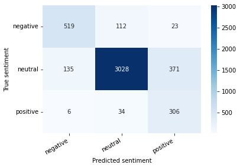

```python
def show_confusion_matrix(confusion_matrix):
    hmap = sns.heatmap(confusion_matrix, annot=True, fmt="d", cmap="Blues")
    hmap.yaxis.set_ticklabels(hmap.yaxis.get_ticklabels(), rotation=0, ha='right')
    hmap.xaxis.set_ticklabels(hmap.xaxis.get_ticklabels(), rotation=30, ha='right')
    plt.ylabel('True sentiment')
    plt.xlabel('Predicted sentiment');

cm = confusion_matrix(test_dataset['label'], test_pred)
df_cm = pd.DataFrame(cm, index=class_names, columns=class_names)
show_confusion_matrix(df_cm)
```

```python
# Сохраняем финальную модель
model.save_pretrained(save_model_folder)
```

### 15. Классификация произвольного текста

```python
text = "С Новым годом!"
```

```python
encoded_text = tokenizer(
    text,
    max_length=MAX_LEN,
    padding='max_length',
    truncation='longest_first',
    return_tensors='pt'
)
```

```python
input_ids = encoded_text['input_ids'].to(model.device)
attention_mask = encoded_text['attention_mask'].to(model.device)
output = model(input_ids, attention_mask)
_, prediction = torch.max(output['logits'], dim=1)
probs = softmax(output['logits'], dim=1)
print(f'Text: {text}')
print(f'Softmax: {probs[0].tolist()}')
print(f'Sentiment: {class_names[prediction]}')
```

```
Text: С Новым годом!
Softmax: [0.004769452381879091, 0.024831846356391907, 0.9703986048698425]
Sentiment: positive
```

### 16. Загрузка сохраненной модели

```python
model = RobertaForFineTuningClassification.from_pretrained(save_model_folder)
```

[output not shown]

```python
model.classifier.out_proj.weight
```

```
Parameter containing:
tensor([[ 0.0166, -0.0081, -0.0106,  ..., -0.0122, -0.0246,  0.0339],
        [-0.0056,  0.0218, -0.0254,  ...,  0.0259,  0.0255, -0.0544],
        [ 0.0063, -0.0137, -0.0141,  ..., -0.0274,  0.0058,  0.0335]],
       requires_grad=True)
```